# Milestone Report

Milton Candela

2/13/2021

# Introduction

This report is for the *Data Science Capstone Project* course on *Coursera*, delivered by *The Johns Hopkins University*. The purpose of this report is to show some exploratory analysis of the data sets given (which contain mainly unstructured text data) and build a simple n-gram model which will be worked across the whole course in order to improve its efficiency, as well as its compatibility, it may be used in order to predict the next word using other languages as well.

## Loading the data

We will be using three text files that contain a series of characters that represent words written by users in three distinct formats:

- Blogs
- News
- Twitter

The three formats have their own language, the different languages included are the following:

- English
- German
- French
- Russian

There are some problems when developing a model which predict the next word, for example, the multiple contractions in French or the multiple nouns in German. So only the English language will be worked on this first report, using bar plots and charts in order to represent the differences between the three text files that correspond to the selected language.

In order to load the data, a function is used so the process can be automated, the **fileRead** function will read all the lines of the document using the **readLines** function, we will store the data in three different variables in order to treat the data separately, the data stored in these character variables will be processed later to work with these unstructured data.

```r
fileRead <- function(file) {
        camino <- paste('data/final/en_US/en_US.', file, '.txt', sep = '') # The path of the files
        con <- file(camino, 'r') # Connection to the file is opened
        doc <- readLines(con, skipNul = TRUE) # The document is read depending on the connection opened
        close(con) # The connection is closed
        return(doc)
}

blogs_file <- fileRead('blogs')
news_file <- fileRead('news')
twitter_file <- fileRead('twitter')
```

## Summary of the data

The data is very messy to visualize, because it mostly contains a series of characters and it is not divided by sentences, the following data frame contains the size, number of lines, as well as the number of words of each file, it is easier to visualize, and illustrates more clearly the unique features of the three text files, as well as their common characteristics.

```r
dfsum <- data.frame(
        File = c('Blogs', 'News', 'Twitter'),
        Size = c(file.size('data/final/en_US/en_US.blogs.txt')/1024/1024,
                 file.size('data/final/en_US/en_US.news.txt')/1024/1024,
                 file.size('data/final/en_US/en_US.twitter.txt')/1024/1024),
        Lines = c(length(blogs_file), length(news_file), length(twitter_file)),
        Words = c(sum(count_words(blogs_file)),
                  sum(count_words(news_file)),
                  sum(count_words(twitter_file)))
        )

dfsum
```

```
##      File     Size   Lines    Words
## 1   Blogs 200.4242  899288 38154238
## 2    News 196.2775   77259  2693898
## 3 Twitter 159.3641 2360148 30218166
```

As the data frame reflect, the twitter file is the most lightest file, but includes many lines comparing to the other two files, this is due to the fact that it represents a lot of tweets separately. This feature of separate lines is seen in the blogs file, because it contains multiple entries that use a lot of colloquial language that represent the almost 40 million words used. Although the news file has the the least amount of lines among the three, it uses more complex words, so it uses the least amount of lines and the least amount of words and still weights the same as the blogs file.

In the next section *Bar plots of the summary*, bar plots will be used in order to spot these differences graphically

## Bar plots of the summary

The following bar plots explain more clearly the differences of the three text files. Each bar plot addresses one of the three features previously presented, and a specific color-coding will be used among the three graphs to identify each file.

```r
colors <- c('gray75', 'lightsalmon', 'lightblue') # Colors will be used
```

### Size plot

The size among the files is very similar and does not represent a big difference, we can see that the twitter file is slightly lower by 40 Mb, but they contain similar size of information, although differently distributed.

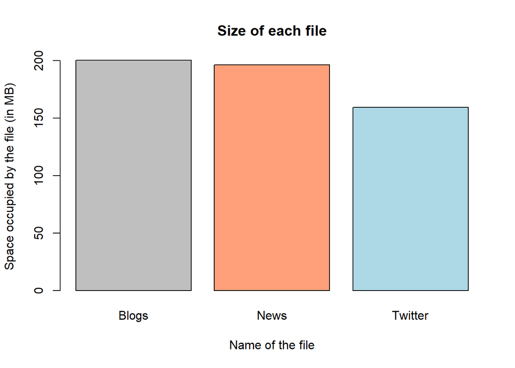

```r
colors <- c('gray75', 'lightsalmon', 'lightblue') # Colors will be used

with(dfsum, barplot(Size, names.arg = File,
     ylab = 'Space occupied by the file (in MB)',
     xlab = 'Name of the file',
     main = 'Size of each file',
     col = colors))
```

### Lines plot

The bar plot representing the number of lines of each document gives us a better view on how the data is distributed, twitter has the most lines but it is because on the structure of the data (which is mainly given by mini entries of text).

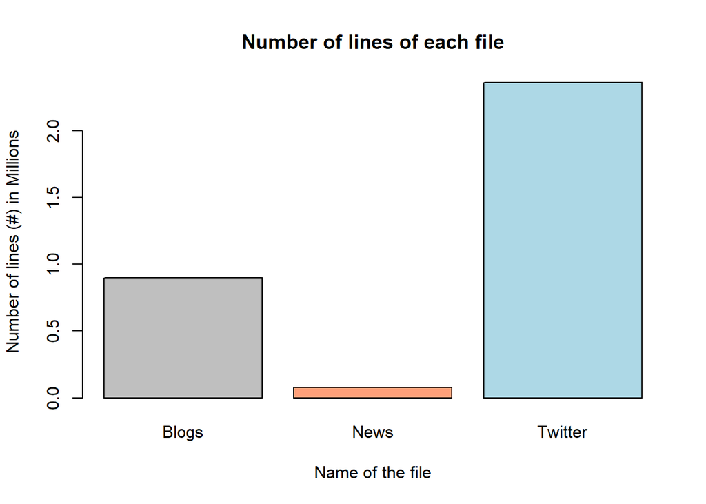

```r
with(dfsum, barplot(Lines/1000000, names.arg = File,
     ylab = 'Number of lines (#) in Millions',
     xlab = 'Name of the file',
     main = 'Number of lines of each file',
     col = colors))
```

### Words plot

The number of words plot is quite interesting, because the news file contains very little words comparing to the other files, this may be due to the type of vocabulary used or due to the inconsistencies of the data. As data coming from a news webpage may be cleaner and more structured when compared on data provided by blogs or twitter, users could use special characters and there is not as many filters as news data has.

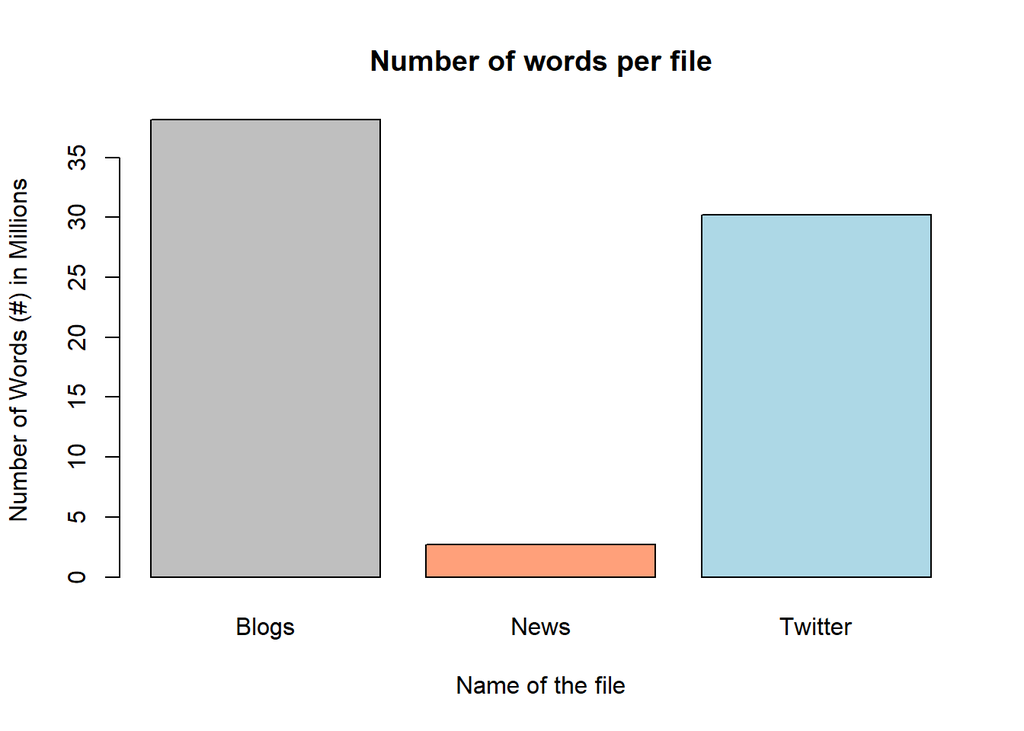

```r
with(dfsum, barplot(Words/1000000, names.arg = File,
     ylab = 'Number of Words (#) in Millions',
     xlab = 'Name of the file',
     main = 'Number of words per file',
     col = colors))
```

## Corpus creation

A corpus will be created so the data can be processed on a more specialized, structured way. A corpus is a set of documents which contains each of the separate files. The encoding used is **UTF-8** because some of the files contained various special characters that made impossible to use the more traditional, structured **ASCII** encoding.

```r
camino <- 'data/final/en_US' # Only the location of the text files is required
engCorpus <- Corpus(DirSource(directory = camino, mode = 'text', encoding = 'UTF-8'))
```

## Corpus cleaning

As I have been saying, the data is very messy and contains a lot of punctuation marks, as well as special characters. So it requires cleaning in order to do the proper text mining, and the further text prediction. To achieve this objective, a function was created by the name of **cleanCorp**, which uses functions included in the **tm** package that make some transformations to a corpus variable.

The transformations used are the following:

- removePunctuation
- stripWhitespace
- tolower

These transformations improve the efficiency of a text-predicting model because it formats all the words in a proper way, this gives the same weight to all the words, even though they are capitalized or they contained a punctuation mark, reducing duplicates.

Also, for this report only the news file will be analyzed completely, because it contains more structured unstructured data than the other files, it also contains fewer words and fewer lines, which makes the computation feasible and significant.

```r
newsCorpus <- NA

cleanCorp <- function(corpus, lower){
        corp <- tm_map(corpus, removePunctuation)
        corp <- tm_map(corp, stripWhitespace)
        corp <- tm_map(corp, content_transformer(tolower))

        return(corp)
}

newsCorpus <- cleanCorp(engCorpus[2]) # The second index represent the news file
```

## Term document matrix

A term document matrix is a matrix which contains all the words included in a document, as well as its frequencies, it will be useful further in the report in order to analyze the text and create the n-grams. I have created a function that transforms a corpus into a term document matrix type of file, and removes some elements (in this case words) that are sparse.

```r
tdmGenerator <- function(corp){
        tdm <- TermDocumentMatrix(corp)

        tdm <- removeSparseTerms(tdm, 0.7) # Maximal allowed sparsity
        return(tdm)
}
```

## Frequency ratio plots

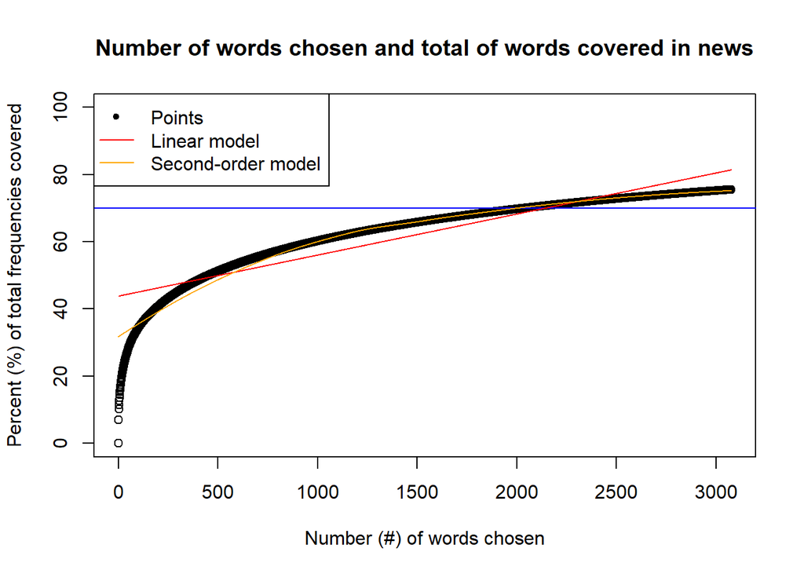

```r
frequency_plots <- function(corpus, file){

        tdm <- tdmGenerator(corpus) # Call to the tdmGenerator helper function

        df_freq <- data.frame(Palabra = tdm$dimnames$Terms, Frecuencia = tdm$v)

        total_freq <- sum(df_freq[,2])

        df_freq <- df_freq[df_freq$Frecuencia > 20, ] # Subset of the data which appeared > 20 times

        df_freq <- df_freq[order(df_freq[,2], decreasing = TRUE),]

        total_words <- length(df_freq[,1])

        max_val <- total_words*0.33 # Using one third of the total words
        step <- 1 # A step of 1 is used to get an accurate plot

        df_freq <- mutate(df_freq, Ratio = (Frecuencia/total_freq) * 100)

        df <- data.frame('Top_1' = df_freq[1,3])

        for (num in c(seq(1, max_val, step))){
               current_num <- paste('Top_', num, sep = '')
               df[,current_num] <- round(sum(df_freq[1:num, 3]),4)
        }

        xdata <- c(0, 1, seq(2,max_val, step))
        ydata <- c(0, df[,1:length(df)])
        ydata <- as.numeric(unlist(ydata))

        plot(ydata ~ xdata, xlim = c(0,max_val), ylim = c(0,100),
                    main = paste('Number of words chosen and total of words covered in', file),
                    xlab = 'Number (#) of words chosen', ylab = 'Percent (%) of total frequencies covered')

        fit <- lm(ydata ~ xdata)
        fit2 <- loess(ydata ~ xdata, degree = 2, span = 0.95)

        abline(h = 70, col = 'blue') # Threshold of 70% of the frequencies of the whole document
        lines(xdata, fit$fitted.values, col = 'red')
        lines(xdata, fit2$fitted, col = 'orange')

        legend(legend = c('Points','Linear model', 'Second-order model'), 'topleft',
        col = c('black', 'red', 'orange'), pch = c(20,-1,-1), lty = c(0,1,1))
}

frequency_plots(newsCorpus, 'news')
```

As it can be seen, there is a great learning curve on the beginning on the graph, this demonstrates that most frequent words are very important and represent most of the vocabulary used by the users. The next data set represent the top 10 words used on the news file, the second column is the frequency in which they are used, and the third column the percentage which these frequencies represent on the whole document.

```r
head(df_freq, 10)
```

```
##    Palabra Frecuencia     Ratio
## 1      the     151153 7.0521320
## 2      and      68159 3.1799982
## 3      for      26944 1.2570882
## 4     that      26281 1.2261555
## 5     with      19736 0.9207947
## 6     said      19164 0.8941077
## 7      was      17615 0.8218382
## 8      his      12099 0.5644860
## 9     from      11630 0.5426045
## 10     but      11574 0.5399918
```

As I have said before, the top words correspond to stop words that correspond to prepositions, these are usually removed when doing binary classification or sentiment analysis because they provide little information about the author of a text or whether a text corresponds to a certain type of text. Although, for the purposes of this investigation (text predicting), these stop words are key in order to know how a person will write next, so these words will be included in order to know the most probable next word.

## Simple n_gram model

The n-grams created are the following:

- 2-gram using **blogs file**
- 3-gram using **twitter file**
- 4-gram using **news file**

The **ngram** function provided by the **ngram** package requires that the data to be in a certain format, and to do not include *NA* values (this values can be obtained via whitespaces). So the **tokenizers** package will be used to tokenize (count the frequency of each word) each file, then these *NA* values will be removed so that the **ngram** function can operate properly.

### 2-gram model

First we get our random sample and set the *n* to 2 (bigram), and remove the *NA* values, these values represent a small percentage of the whole file, but it affects our n-gram performance and creation.

```r
## Creating a 2-gram model using 25% of the blogs file

set.seed(1023)

n <- 2

num_lines <- dfsum[dfsum$File == 'Blogs', 'Lines'] * .25 # Considering 25% of the total lines

doc <- blogs_file[sample(1:num_lines)]

bitokens <- unlist(tokenize_ngrams(doc, n = n))
print(paste('Ratio of NAs in the bitokens: ', round(sum(is.na(bitokens))/length(bitokens) * 100, digits = 4), '%', sep = ''))
```

```
## [1] "Ratio of NAs in the bitokens: 0.0264%"
```

As the *NA* are being removed, then we input our bitokens to the **ngram** function.

```r
bitoken_na <- na.omit(bitokens)
bigram <- ngram(bitoken_na, n)

head(get.phrasetable(bigram), 10)
```

```
##      ngrams  freq        prop
## 1   of the  46590 0.005011116
## 2   in the  38212 0.004109997
## 3   to the  21562 0.002319160
## 4   on the  18854 0.002027894
## 5    to be  16976 0.001825901
## 6  and the  14520 0.001561739
## 7  for the  14324 0.001540657
## 8    i was  12510 0.001345548
## 9    and i  12319 0.001325004
## 10   it is  11944 0.001284670
```

These are the most common pairs from the blogs file, they mainly consist of *the* and a preposition, because these are the most common types of words in the English language, the informal repetitive language used in blogs also affect on these results.

### 3-gram model

For the trigram model, a similar methodology is used, but we are focusing on the twitter file and changing the *n* value to 3, instead of 2. The seed had been modified to maintain the integrity of this new model and reinforce which is the seed that leads to the current calculation.

```r
## Creating a 3-gram model using 25% of the twitter file

set.seed(1022)

n <- 3

num_lines <- dfsum[dfsum$File == 'Twitter', 'Lines'] * .25 # Considering 25% of the total lines

doc <- twitter_file[sample(1:num_lines)]

tritokens <- unlist(tokenize_ngrams(doc, n = n))
print(paste('Ratio of NAs in the tritokens: ', round(sum(is.na(tritokens))/length(tritokens) * 100, digits = 4), '%', sep = ''))
```

```
## [1] "Ratio of NAs in the tritokens: 0.2541%"
```

There are also *NA* values on this file, but these are not significant to the whole file.

```r
tritoken_na <- na.omit(tritokens)
trigram <- ngram(tritoken_na, n)

head(get.phrasetable(trigram), 10)
```

```
##                 ngrams freq         prop
## 1      thanks for the  5843 0.0009165853
## 2  looking forward to  2249 0.0003527983
## 3       thank you for  2196 0.0003444842
## 4          i love you  2053 0.0003220519
## 5      for the follow  1962 0.0003077769
## 6           i want to  1870 0.0002933449
## 7         going to be  1866 0.0002927175
## 8       can't wait to  1794 0.0002814229
## 9            a lot of  1552 0.0002434606
## 10            to be a  1500 0.0002353034
```

Looking at these pairs, we can grasp some frequent words used on twitter, these correspond to *thanks for the* (which is probably followed by *follow*), or *for the follow*. This denotes an important factor, that the source of data affects which is the most probable word, the type of language is different depending on the sources of information.

This factor makes that the model take one of the following routes:

- Declare to which user is the model being addressed
- Generate a generalizable model using the three types of writing

The first option can make the model very accurate when addressing a certain type of user, while the second model can fit every type of user, but having (probably) a poor performance when compared to the specialized model.

### 4-gram model

This is the last model, we will be using the news file because it has more structured sentences, and this is an important factor when creating a great number of n-grams, these words are the least probable because they must be together, but are more accurate because they consider more words than the previous n-grams.

```r
## Creating a 4-gram model using 25% of the news file

set.seed(1021)

n <- 4

num_lines <- dfsum[dfsum$File == 'News', 'Lines'] * .25 # Considering 25% of the total lines

doc <- news_file[sample(1:num_lines)]

foutokens <- unlist(tokenize_ngrams(doc, n = n))
print(paste('Ratio of NAs in the tritokens: ', round(sum(is.na(foutokens))/length(foutokens) * 100, digits = 4), '%', sep = ''))
```

```
## [1] "Ratio of NAs in the tritokens: 0.0843%"
```

There are also a few *NA* values involved, but they can be removed via the **na.omit** function.

```r
foutoken_na <- na.omit(foutokens)
fougram <- ngram(foutoken_na, n)

head(get.phrasetable(fougram), 10)
```

```
##                   ngrams freq         prop
## 1    for the first time    50 8.097533e-05
## 2        the end of the    46 7.449731e-05
## 3         at the end of    41 6.639977e-05
## 4   said in a statement    39 6.316076e-05
## 5       the rest of the    39 6.316076e-05
## 6      in the middle of    36 5.830224e-05
## 7       one of the most    35 5.668273e-05
## 8      when it comes to    32 5.182421e-05
## 9         is one of the    31 5.020471e-05
## 10 at the university of    31 5.020471e-05
```

Quite interesting results given by these last n-gram, the bias included by the language is observed in this file, as *said in a statement* appears as a frequent group of words. The group of four sequential words are not frequently encountered (as it can be seen on the low prop on the prop column), but the text predicting model will first start with the biggest n-gram created, and if it does not found a match then it will go the (n-1)-gram model, and so on until it finds a match at least with the monomer.